# sir_model

## The SIR model - flattening the curve

Doğukan E. Türköz

The [SIR model](https://en.wikipedia.org/wiki/Compartmental_models_in_epidemiology#The_SIR_model) is given by the following system of ODEs

$$ \dot S = - \frac{\beta S I}{N}, \quad \dot I = \frac{\beta S I}{N} - \gamma I, \quad \dot R = \gamma I, $$

where $S$ is the number of susceptible individuals, $I$ is the number of infectious individuals, $R$ is the number of recovered or removed individuals. $N$ is the total number of individuals, i.e. $N = S+I+R$. One can easily verify that $\dot N = 0$ by adding the three equations. Hence $N$ is constant. $\beta$ and $\gamma$ are parameters: $\beta$ is the average number of contacts per person per time, $\gamma$ is the reciprocal of the time an individual remains infectious. The basic reproduction ratio is given by $R_0 = \beta \;/ \;\gamma$. We are potentially interested in cases where the parameter $\beta$ is not constant in time.

```python
# import libraries

import numpy as np
import matplotlib.pyplot as plt
from scipy.integrate import odeint
```

## Baseline case

The Python code cells below compute numerical solutions to this model by calling the SciPy ODE solver odeint.

Results are shown for specific parameter values: $\beta = 0.3$ and $\gamma = 0.1$, corresponding to $R_0 = 3$. The initial conditions are $S(0) = 10^6 - 5$, $I(0) = 5$, and $R(0) = 0$. So, we start with only 5 infectious individuals in a population of size $N=10^6$.

The first plot below shows the time series of the three variables. Time can be thought of a measured in days so 180 days is about 6 months. The model captures the basics of the disease progression where the number of infectious individuals initially grows (outbreak). Eventually the number of infections individuals reaches a peak and thereafter decreases.

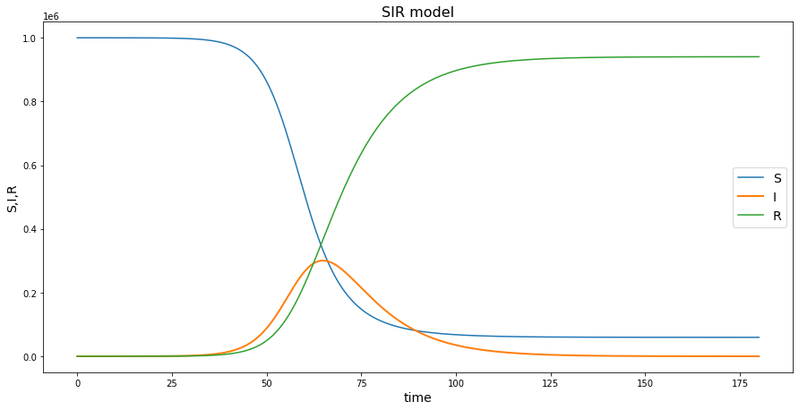

```python
# --- First define the RHS of ODE system --- #

def SIR(y, t):
    # returns RHS of the SIR model
    S, I, R = y

    beta = 0.3
    gamma = 0.1

    N = S + I + R
    Sdot = -beta * S * I / N
    Idot = beta * S * I / N - gamma * I
    Rdot = gamma * I

    return Sdot, Idot, Rdot

# --- Problem setup --- #

# Set initial conditions and put into array y0
S0 = 10.0**6 -5
I0 = 5
R0 = 0
y0 = np.array([S0, I0, R0])

# set up time grid for solution
tf = 180
Nsteps = 1800
t= np.linspace(0, tf, Nsteps+1)

# --- Call the ODE solver and extract solutions --- #

y_sol = odeint(SIR, y0, t)

# extract S, I, R from the solution array y
S = y_sol[:,0]
I = y_sol[:,1]
R = y_sol[:,2]

# --- Plot various interesting things --- #

# plot the time evolution of the S, I, R
plt.figure(figsize=(15,7.2))
plt.plot(t, S, label="S")
plt.plot(t, I, lw = 2, label="I")
plt.plot(t, R, label="R")



# labels etc
plt.xlabel("time", fontsize=14)
plt.ylabel("S,I,R", fontsize=14)
plt.title("SIR model", fontsize=16)
plt.legend(fontsize=14)
plt.show()
```

The second plot shows a phase portrait in the $(S,I)$ plane. A diamond shows the initial condition, and a circle shows the final state. The plots show a different view of the disease progression. Note that at the final time, there are some individuals who did not contract the disease ($S(t_f) > 0$).

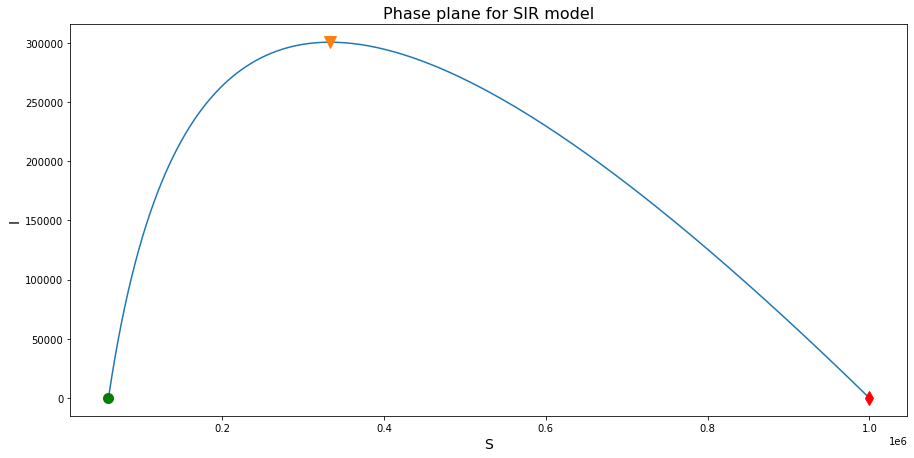

```
At the end of the simulation, the final value of S, I, and R are (rounded):
S(t=tf) = 59531
I(t=tf) = 51
R(t=tf) = 940418
The (rounded) maximum value of I is 300464, which occurs when (rounded) S = 332721.
```

```python
#find where the max value for I occurs
max_I = np.amax(I)
t_of_max = np.where(I == np.amax(I))
svalue_atmax = S[t_of_max]

# plot the evolution in the S,I phase plane
plt.figure(figsize=(15,7.2))
plt.plot(S, I)

# labels etc
plt.xlabel("S", fontsize=14)
plt.ylabel("I", fontsize=14)
plt.title("Phase plane for SIR model", fontsize=16)

# put some markers to show initial, final, and maximum state
plt.plot(S[0], I[0], 'rd', markersize = 10)
plt.plot(S[-1], I[-1], 'go', markersize = 10)
plt.plot(S[t_of_max], I[t_of_max], 'v', markersize = 12)
plt.show()

# --- Report the final values of S, I, R, and max(I)  --- #

print("At the end of the simulation, the final value of S, I, and R are (rounded):")
print("S(t=tf) =", round(S[-1]))
print("I(t=tf) =", round(I[-1]))
print("R(t=tf) =", round(R[-1]))
print("The (rounded) maximum value of I is " + str(round(max_I)) + ", which occurs when (rounded) S = " + str(round(svalue_atmax[0])) + "." )
```

## Prior immunity

One can study the basic effect of immunity with the SIR model by starting from an initial condition in which a percentage of the population is in the $R$ class already. Think of these as individuals who have been removed from $S$ and put into $R$, either because they have prior natural immunity or because they have been vaccinated. Either way, they are immune and hence not susceptible at the start of the disease outbreak.

The Python code cells below compute numerical solutions to this model by calling the SciPy ODE solver odeint.

Results are shown for specific parameter values: $\beta = 0.3$ and $\gamma = 0.1$, corresponding to $R_0 = 3$. The initial conditions are $S(0) = 10^6 - 200005$, $I(0) = 5$, and $R(0) = 200000$. So, we start with only 5 infectious individuals in a population of size $N=10^6$, but we now also have $200000$ recovered individuals $(20 \%$ of $N$).

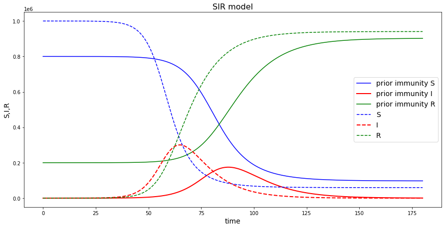

```python
# --- Problem setup --- #

# Set initial conditions and put into array y0
pr_S0 = 10.0**6 -200005
pr_I0 = 5
pr_R0 = 200000
pr_y0 = np.array([pr_S0, pr_I0, pr_R0])

# --- Call the ODE solver and extract solutions --- #

pr_y_sol = odeint(SIR, pr_y0, t)

# extract S, I, R from the solution array y
pr_S = pr_y_sol[:,0]
pr_I = pr_y_sol[:,1]
pr_R = pr_y_sol[:,2]

# --- Plot various interesting things --- #

# plot the time evolution of the S, I, R
plt.figure(figsize=(15,7.2))
plt.plot(t, pr_S, label="prior immunity S", color = "b")
plt.plot(t, pr_I, lw = 2, label="prior immunity I", color = "red")
plt.plot(t, pr_R, label="prior immunity R", color = "green")
plt.plot(t, S, '--', label="S", color = "b")
plt.plot(t, I, '--', lw = 2, label="I", color = "red")
plt.plot(t, R, '--', label="R", color = "green")

# labels etc
plt.xlabel("time", fontsize=14)
plt.ylabel("S,I,R", fontsize=14)
plt.title("SIR model", fontsize=16)
plt.legend(fontsize=14)
plt.show()
```

The second plot compares the phase portraits in the $(S,I)$ plane of the number of infectious individuals with and without prior immunity. The plots show a different view of the disease progression. A diamond shows the initial condition, and a circle shows the final state in both cases. The green triangle and red triangle show the maximum number of infected individuals in both cases. Note that at the final time, the number of individuals who did not contract the disease is much higher with prior immunity.

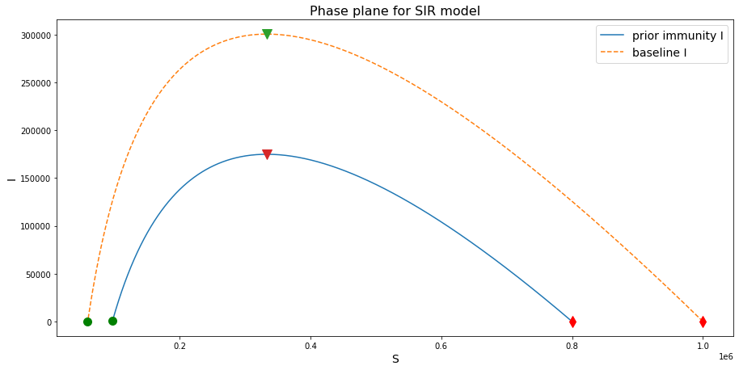

```
At the end of the simulation, the final value of S, I, and R with prior immunity are (rounded):
Prior immunity S(t=tf) = 97384
Prior immunity I(t=tf) = 635
Prior immunity R(t=tf) = 901982
The (rounded) maximum value of I with prior immunity is 174846, which was 300464 for the baseline case.
```

```python
#find where the max value for pr_I occurs
max_pr_I = np.amax(pr_I)
t_of_max_pr_I = np.where(pr_I == np.amax(pr_I))
svalue_atmax_pr_I = S[t_of_max_pr_I]

# plot the evolution in the S,I phase plane
plt.figure(figsize=(15,7.2))
plt.plot(pr_S, pr_I, label="prior immunity I")
plt.plot(S, I, '--', label="baseline I")

# labels etc
plt.xlabel("S", fontsize=14)
plt.ylabel("I", fontsize=14)
plt.title("Phase plane for SIR model", fontsize=16)

# put some markers to show initial, final, and maximum states
plt.plot(S[0], I[0], 'rd', markersize = 10)
plt.plot(S[-1], I[-1], 'go', markersize = 10)
plt.plot(pr_S[0], pr_I[0], 'rd', markersize = 10)
plt.plot(pr_S[-1], pr_I[-1], 'go', markersize = 10)
plt.plot(S[t_of_max], I[t_of_max], 'v', markersize = 12)
plt.plot(pr_S[t_of_max_pr_I], pr_I[t_of_max_pr_I], 'v', markersize = 12)

plt.legend(fontsize=14)
plt.show()

# --- Report the final values of S, I, R, and max(I)  --- #

print("At the end of the simulation, the final value of S, I, and R with prior immunity are (rounded):")
print("Prior immunity S(t=tf) =", round(pr_S[-1]))
print("Prior immunity I(t=tf) =", round(pr_I[-1]))
print("Prior immunity R(t=tf) =", round(pr_R[-1]))

# we are only asked to print max(I) this time
print("The (rounded) maximum value of I with prior immunity is " + str(round(max_pr_I)) + ", which was " + str(round(max_I)) + " for the baseline case.")
```

This plot shows the time series for $I(t)$ with and without prior immunity. By excluding $S(t)$ and $R(t)$, the comparison between the two infection curves is clearer. We have successfully flattened the curve. We also note that with prior immunity, the peak of the infected individuals curve occured later than the peak of the infected individuals curve for the baseline case.

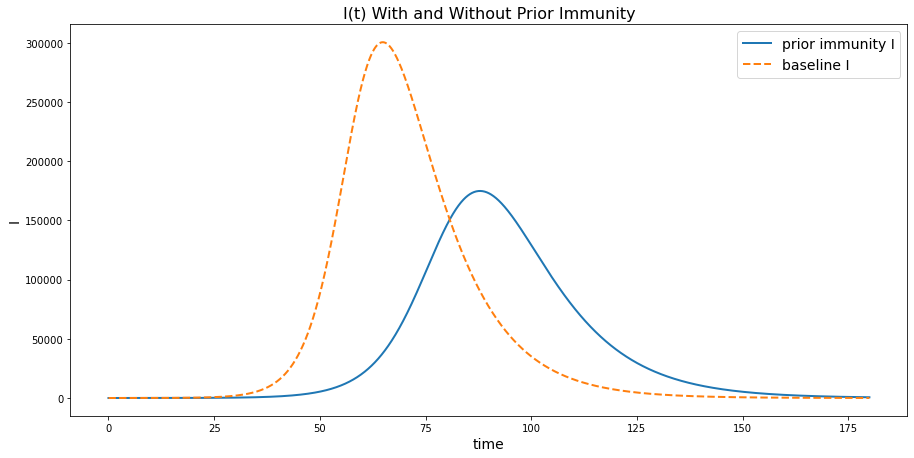

```python
# plot the time evolution of I with and without prior immunity

plt.figure(figsize=(15,7.2))
plt.plot(t, pr_I, lw = 2, label="prior immunity I")
plt.plot(t, I, '--', lw = 2, label="baseline I")

#labels etc
plt.xlabel("time", fontsize=14)
plt.ylabel("I", fontsize=14)
plt.title("I(t) With and Without Prior Immunity", fontsize=16)
plt.legend(fontsize=14)
plt.show()
```

## Social distancing

One can model [social distancing](https://en.wikipedia.org/wiki/Social_distancing), or a mask mandate, by varying the parameter $\beta$ that controls the rate of infection. We will use the following simple approximation. When a mask mandate is in effect, the parameter $\beta$ will be reduced to 0.24, otherwise it will be 0.3, as in the baseline case. More specifically, we will consider $\beta$ to change between these two values according to:

$$ \beta = 0.3 \quad {\rm if} \quad t \le t_{m} \\ \beta = 0.24 \quad {\rm if} \quad t_{m} < t \le t_{m}+30 \\ \beta = 0.3 \quad {\rm if} \quad t_{m}+30 < t $$

$t_m$ corresponds to the time the mask mandate goes into effect. We consider a 30-day mandate period and so $t_m+30$ corresponds to the time the mask mandate is lifted.

Note, that with $\beta$ varying with time, the ODE is no longer autonomous and the reproduction rate is no longer constant.

As in the baseline case, the initial conditions are $S(0) = 10^6 - 5$, $I(0) = 5$, and $R(0) = 0$. So, we start with only 5 infectious individuals in a population of size $N=10^6$.

We first write a Python function to compute the right-hand-side of the SIR model with time-dependent $\beta$ given by the above expression. We will take $t_m = 43$, as this value for $t_m$ flattens the infected individuals curve significantly.

```python
def soc_SIR(y, t):
    # returns RHS of the SIR model
    S, I, R = y

    # we implement the tm value discussed above to define beta in piecewise form

    tm = 43
    beta = 0
    if t <= tm or tm + 30 < t:
        beta = 0.3
    else:
        beta = 0.24

    gamma = 0.1

    N = S + I + R
    Sdot = -beta * S * I / N
    Idot = beta * S * I / N - gamma * I
    Rdot = gamma * I

    return Sdot, Idot, Rdot
```

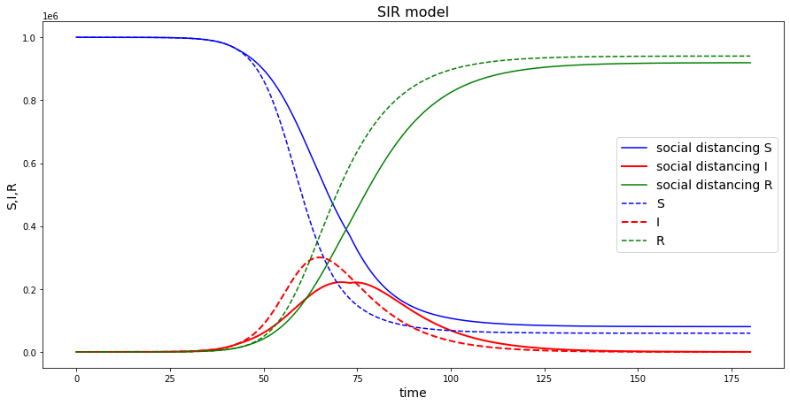

```python
# --- Problem setup --- #

# Set initial conditions and put into array y0
soc_S0 = 10.0**6 -5
soc_I0 = 5
soc_R0 = 0
soc_y0 = np.array([soc_S0, soc_I0, soc_R0])

# --- Call the ODE solver and extract solutions --- #

soc_y_sol = odeint(soc_SIR, soc_y0, t)

# extract S, I, R from the solution array y
soc_S = soc_y_sol[:,0]
soc_I = soc_y_sol[:,1]
soc_R = soc_y_sol[:,2]

# --- Plot various interesting things --- #

# plot the time evolution of the S, I, R
plt.figure(figsize=(15,7.2))
plt.plot(t, soc_S, label="social distancing S", color = "b")
plt.plot(t, soc_I, lw = 2, label="social distancing I", color = "red")
plt.plot(t, soc_R, label="social distancing R", color = "green")
plt.plot(t, S, '--', label="S", color = "b")
plt.plot(t, I, '--', lw = 2, label="I", color = "red")
plt.plot(t, R, '--', label="R", color = "green")

# labels etc
plt.xlabel("time", fontsize=14)
plt.ylabel("S,I,R", fontsize=14)
plt.title("SIR model", fontsize=16)
plt.legend(fontsize=14)
plt.show()
```

The second plot compares the phase portraits in the $(S,I)$ plane of the number of infectious individuals with and without social distancing. The plots show a different view of the disease progression. A diamond shows the initial condition, and a circle shows the final state in both cases. The green triangle and red triangle show the maximum number of infected individuals in both cases. Note that at the final time, the number of individuals who did not contract the disease is higher with social distancing.

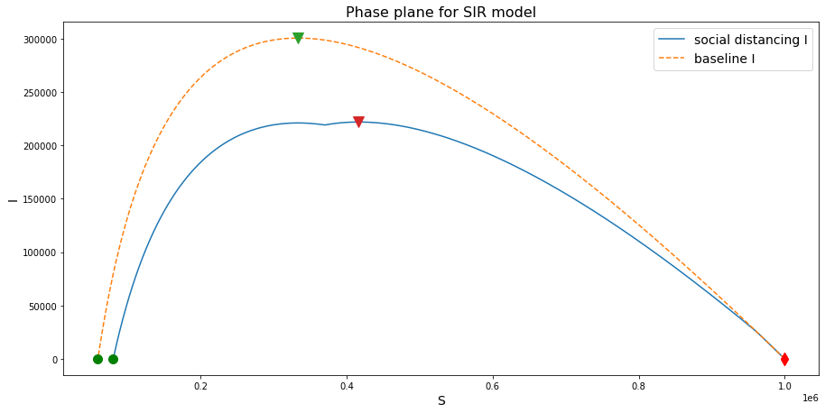

```
At the end of the simulation, the final value of S, I, and R with social distancing are (rounded):
Social distancing S(t=tf) = 80500
Social distancing I(t=tf) = 174
Social distancing R(t=tf) = 919326
The (rounded) maximum value of I with social distancing is 221851, which was 300464 for the baseline case.
```

```python
#find where the max value for soc_I occurs
max_soc_I = np.amax(soc_I)
t_of_max_soc_I = np.where(soc_I == np.amax(soc_I))
svalue_atmax_soc_I = S[t_of_max_soc_I]

# plot the evolution in the S,I phase plane
plt.figure(figsize=(15,7.2))
plt.plot(soc_S, soc_I, label="social distancing I")
plt.plot(S, I, '--', label="baseline I")

# labels etc
plt.xlabel("S", fontsize=14)
plt.ylabel("I", fontsize=14)
plt.title("Phase plane for SIR model", fontsize=16)

# put some markers to show initial, final, and maximum states
plt.plot(S[-1], I[-1], 'go', markersize = 10)
plt.plot(S[0], I[0], 'rd', markersize = 10)
plt.plot(soc_S[0], soc_I[0], 'rd', markersize = 10)
plt.plot(soc_S[-1], soc_I[-1], 'go', markersize = 10)
plt.plot(S[t_of_max], I[t_of_max], 'v', markersize = 12)
plt.plot(soc_S[t_of_max_soc_I], soc_I[t_of_max_soc_I], 'v', markersize = 12)
plt.legend(fontsize=14)
plt.show()

# --- Report the final values of S, I, R, and max(I)  --- #

print("At the end of the simulation, the final value of S, I, and R with social distancing are (rounded):")
print("Social distancing S(t=tf) =", round(soc_S[-1]))
print("Social distancing I(t=tf) =", round(soc_I[-1]))
print("Social distancing R(t=tf) =", round(soc_R[-1]))

# we are only asked to print max(I) this time
print("The (rounded) maximum value of I with social distancing is " + str(round(max_soc_I)) + ", which was " + str(round(max_I)) + " for the baseline case.")
```

The bump near the top of the infected individuals with social distancing curve indicates that our $t_m$ value was near optimal. It shows that social distancing showed its full effect when the infected individuals curve was increasing at a high rate. We also note that with social distancing, the peak of the infected individuals curve occured later than the peak of the infected individuals curve for the baseline case.

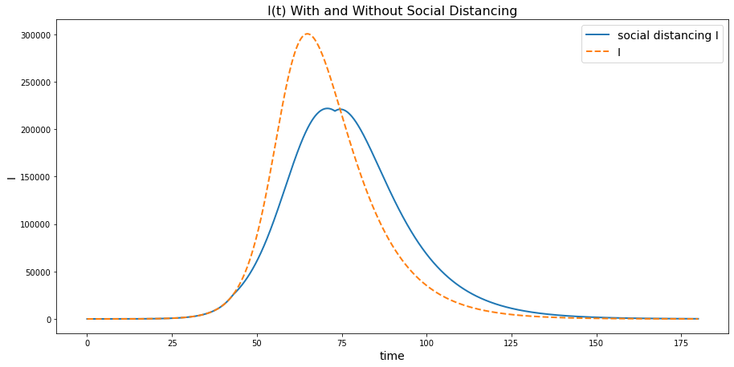

```python
# plot the time evolution of I with and without prior immunity

plt.figure(figsize=(15,7.2))
plt.plot(t, soc_I, lw = 2, label="social distancing I")
plt.plot(t, I, '--', lw = 2, label="I")

#labels etc
plt.xlabel("time", fontsize=14)
plt.ylabel("I", fontsize=14)
plt.title("I(t) With and Without Social Distancing", fontsize=16)
plt.legend(fontsize=14)
plt.show()
```

**Concluding Remark**: In an ideal scenario, it is seen from our analysis that a combination of prior immunity (perhaps in the form of vaccination) and social distancing (perhaps in the form of a maske mandate for a certain period of time) would flatten the curve most effectively, and hence, decrease the pressure over the healthcare systems.